# Homework 2: Bike Sharing Data Visualization

Daniel Kwik

## Read Data

Read the data from the CSV file.

```r
daily_rides <- read_csv("data/day.csv")
```

The following are two different ways of getting a quick look at the data. (Which one looks better in a report? Which one is more useful to a programmer?)

```r
daily_rides %>% glimpse()
```

```
## Rows: 1,462
## Columns: 13
## $ date         <date> 2011-01-01, 2011-01-01, 2011-01-02, 2011-01-02, 2011-01-…
## $ rider_type   <chr> "casual", "registered", "casual", "registered", "casual",…
## $ rides        <dbl> 331, 654, 131, 670, 120, 1229, 108, 1454, 82, 1518, 88, 1…
## $ season       <chr> "W", "W", "W", "W", "W", "W", "W", "W", "W", "W", "W", "W…
## $ year         <dbl> 2011, 2011, 2011, 2011, 2011, 2011, 2011, 2011, 2011, 201…
## $ holiday      <chr> "N", "N", "N", "N", "N", "N", "N", "N", "N", "N", "N", "N…
## $ workingday   <chr> "weekend", "weekend", "weekend", "weekend", "workday", "w…
## $ day_of_week  <dbl> 6, 6, 0, 0, 1, 1, 2, 2, 3, 3, 4, 4, 5, 5, 6, 6, 0, 0, 1, …
## $ weather_type <dbl> 2, 2, 2, 2, 1, 1, 1, 1, 1, 1, 1, 1, 2, 2, 2, 2, 1, 1, 1, …
## $ temp         <dbl> 8.175849, 8.175849, 9.083466, 9.083466, 1.229108, 1.22910…
## $ feels_like   <dbl> 7.999250, 7.999250, 7.346774, 7.346774, -3.499270, -3.499…
## $ humidity     <dbl> 0.805833, 0.805833, 0.696087, 0.696087, 0.437273, 0.43727…
## $ wind_speed   <dbl> 10.749882, 10.749882, 16.652113, 16.652113, 16.636703, 16…
```

```r
daily_rides %>% head() %>% kable()
```

| date | rider_type | rides | season | year | holiday | workingday | day_of_week | weather_type | temp | feels_like | humidity | wind_speed |
| --- | --- | --- | --- | --- | --- | --- | --- | --- | --- | --- | --- | --- |
| 2011-01-01 | casual | 331 | W | 2011 | N | weekend | 6 | 2 | 8.175849 | 7.999250 | 0.805833 | 10.74988 |
| 2011-01-01 | registered | 654 | W | 2011 | N | weekend | 6 | 2 | 8.175849 | 7.999250 | 0.805833 | 10.74988 |
| 2011-01-02 | casual | 131 | W | 2011 | N | weekend | 0 | 2 | 9.083466 | 7.346774 | 0.696087 | 16.65211 |
| 2011-01-02 | registered | 670 | W | 2011 | N | weekend | 0 | 2 | 9.083466 | 7.346774 | 0.696087 | 16.65211 |
| 2011-01-03 | casual | 120 | W | 2011 | N | workday | 1 | 1 | 1.229108 | -3.499270 | 0.437273 | 16.63670 |
| 2011-01-03 | registered | 1229 | W | 2011 | N | workday | 1 | 1 | 1.229108 | -3.499270 | 0.437273 | 16.63670 |

## Exercise 1: Label days of week

I first determined which two numbers corresponded to data that fell on weekend, looking at workingday. I found that 0 and 6 fell on weekends. Assuming that 0-6 runs consecutively from the start of the week to the end of the week, 0 will be Sunday, while 6 will be Saturday.

```r
daily_rides <- daily_rides %>%
  mutate(day_of_week = factor(day_of_week, levels = c(0, 1, 2, 3, 4, 5, 6), labels = c("Sunday", "Monday", "Tuesday", "Wednesday", "Thursday", "Friday", "Saturday")))
```

## Exercise 2: Describe a row

A row contains the type of rider and number of rides on a particular date,including information on whether the day was a holiday, workday, and the day of the week.

## Exercise 3: Rides by date, by rider type

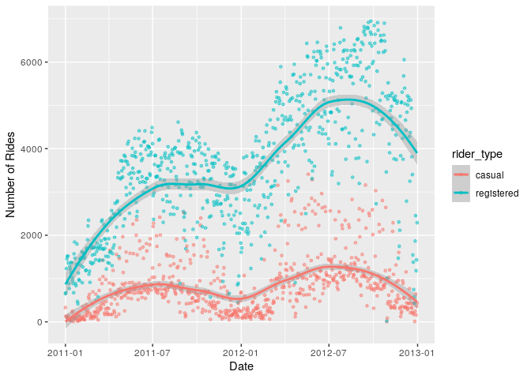

```r
ggplot(daily_rides, aes(x = date, y = rides, color = rider_type)) +
  geom_point(size = 1, alpha = 0.5) +
  labs( x = "Date", y = "Number of Rides") +
  geom_smooth()
```

This plots show the number of rides over time. It segments the data by casual or registered rider types through color, and also provides a trendline for each segment.

## Exercise 4: Mapping vs Faceting

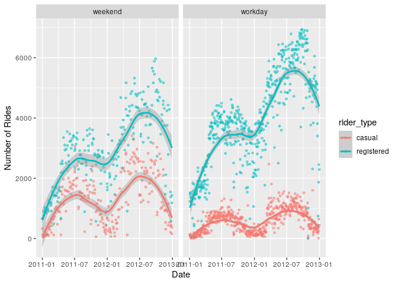

```r
ggplot(daily_rides, aes(x = date, y = rides, color = rider_type)) +
  geom_point(size = 1, alpha = 0.5) +
  labs( x = "Date", y = "Number of Rides") +
  geom_smooth() +
  facet_wrap(vars(workingday))
```

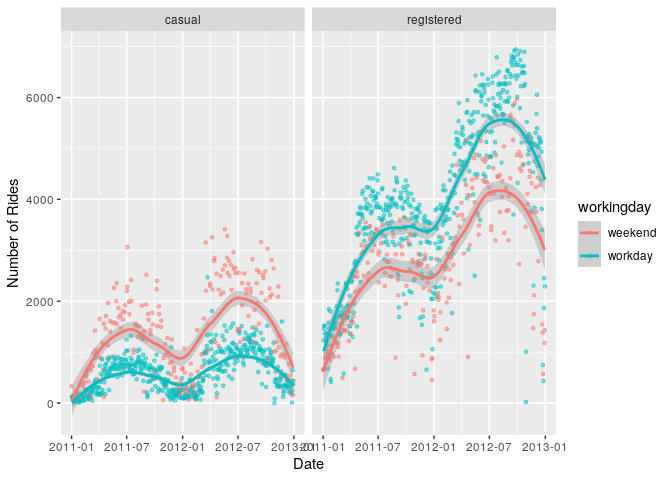

```r
ggplot(daily_rides, aes(x = date, y = rides, color = workingday)) +
  geom_point(size = 1, alpha = 0.5) +
  labs( x = "Date", y = "Number of Rides") +
  geom_smooth() +
  facet_wrap(vars(rider_type))
```

The first plot shows number of rides over time, color segmenting rider type by color, faceted by workingday. The second plot shows number of rides over time, color segmenting rider type by workingday, faceted by rider type. The second plot allows us to see the day of preference to ride for casual and registered riders, whether weekend or workday. We see in plot 2 for example, that casual riders tend to ride predominantly in the weekend, due to the higher smoothing line in red, whereas registered riders tend to ride on workdays (with the blue line being higher). The first plot on the other hand, helps us compare rides on the weekend vs the workdays, specifically, whether rides (casual or registered) are higher on workdays or weekends.

## Exercise 5: How does ridership vary over a typical week?

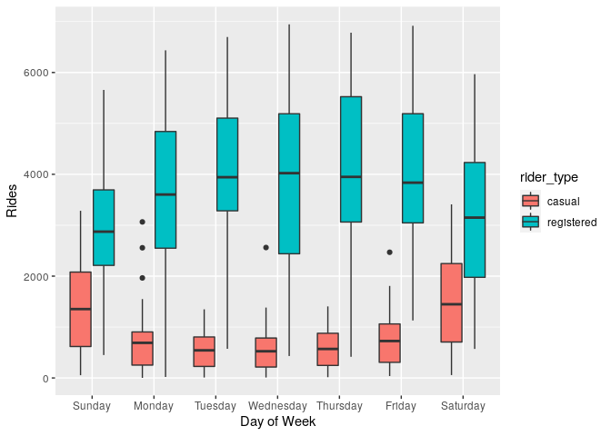

```r
ggplot(data = daily_rides, aes(x = day_of_week, y = rides, fill = rider_type))+
  geom_boxplot() +
  labs(x = "Day of Week", y = "Rides")
```

This plot gives us in the format of boxplots, the day of the week and their corresponding number of rides. The boxplots allow us to know the interquartile ranges as well as the min and max for each day of the week.

## Exercise 6: Plot of your choice

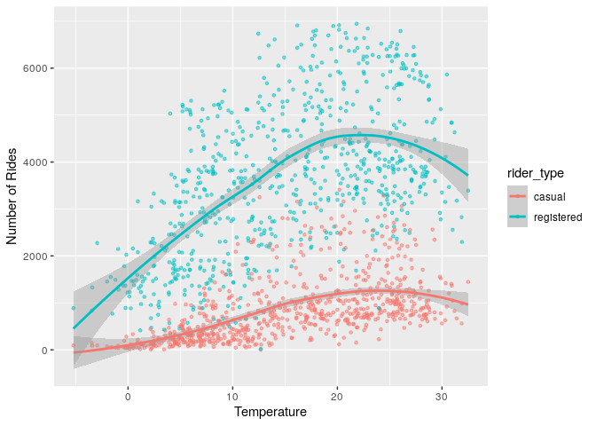

```r
ggplot(daily_rides, aes(x = temp, y = rides, color = rider_type)) +
  geom_point(size = 1, alpha = 0.5) +
  labs( x = "Temperature", y = "Number of Rides") +
  geom_smooth()
```

This plot tells us the relationship between number of rides and temperature, segmented by rider type through color. This tells me that the temperature that is associated with the most number of rides is between the range of 20-25 degree celsius.